# Keras-stock_DNN-tutorial-울산기업 조사

```python
%pylab inline
```

주식 데이터를 불러오기 위한 `pandas-datareader`를 설치해 주세요.

```python
mpl.rcParams['font.family'] = 'NanumGothic'
```

```python
!pip install -U pandas-datareader
```

# 데이터 가져오기

```python
import pandas as pd
```

```python
import pandas_datareader as pdr
```

krx 홈페이지에서 상장된 주식의 종목코드 정보를 가져옵니다.

```python
company_df = pd.read_html('http://kind.krx.co.kr/corpgeneral/corpList.do?method=download', header=0)[0]
```

울산광역시 상장회사 목록을 한 번 볼까요?

```python
company_df[ company_df['지역']=='울산광역시' ]
```

|  | 회사명 | 종목코드 | 업종 | 주요제품 | 상장일 | 결산월 | 대표자명 | 홈페이지 | 지역 |
| --- | --- | --- | --- | --- | --- | --- | --- | --- | --- |
| 5 | KG케미칼 | 1390 | 기초 화학물질 제조업 | 콘크리트혼화제, 비료, 친환경농자재, 수처리제 | 1989-08-25 | 12월 | 곽정현, 김재익 | http://www.kgchem.co.kr | 울산광역시 |
| 311 | 덕양산업 | 24900 | 자동차 신품 부품 제조업 | 자동차부품(CRASH PAD,TRIM PANEL) 제조,판매 | 1997-06-23 | 12월 | 윤성희, 손동인, 한상욱(각자대표이사) | http://www.duckyang.co.kr | 울산광역시 |
| 315 | 디티알오토모티브 | 7340 | 일차전지 및 축전지 제조업 | 자동차용 밧데리 | 1988-09-24 | 12월 | 김상헌 김원종 | http://www.x-probattery.co.kr | 울산광역시 |
| 359 | 큐로 | 15590 | 일반 목적용 기계 제조업 | 열교환기,압력용기,저장탱크,산업용보일러 제조 | 1989-05-27 | 12월 | 서상훈 | http://www.curo.co.kr | 울산광역시 |
| 367 | 한국프랜지공업 | 10100 | 자동차 신품 부품 제조업 | 자동차부품(제동,구동장치),프랜지(관이음쇠),철구조물,산업기계 제조 | 1987-10-02 | 12월 | 이현덕 | http://www.kofco.com | 울산광역시 |
| 543 | 클리노믹스 | 352770 | 의료용품 및 기타 의약 관련제품 제조업 | Geno Series, CD-PRIME, Cancer Prime | 2020-12-04 | 12월 | 김병철,정종태 | http://www.clinomics.com | 울산광역시 |
| 632 | 롯데정밀화학 | 4000 | 기초 화학물질 제조업 | 염소·셀룰로스계열, 암모니아 계열, 전자재료 등 화학제품 제조 | 1976-04-15 | 12월 | 정경문 | http://www.lottefinechem.com | 울산광역시 |
| 639 | 미원화학 | 134380 | 기타 화학제품 제조업 | 계면활성제, 황산및분황 | 2011-02-15 | 12월 | 정규식 | http://www.miwonchemicals.com | 울산광역시 |
| 655 | 센트랄모텍 | 308170 | 자동차 신품 부품 제조업 | 이너레이스, 오디 클러치보스, 로터샤프트, 슬리브기어, 컨트롤 암, 엑슬 | 2019-11-25 | 12월 | 이종철, 강태룡 | http://www.centralmotek.co.kr | 울산광역시 |
| 656 | 송원산업 | 4430 | 기타 화학제품 제조업 | 폴리머첨가제(PVC안정제,산화방지제),폴리우레탄수지,프라스틱첨가제 제조 | 1977-06-25 | 12월 | 김충식 대표이사 | http://www.songwon.com | 울산광역시 |
| 681 | 진양화학 | 51630 | 플라스틱제품 제조업 | 레쟈,바닥재 제조 | 2001-01-29 | 12월 | 김상용 | http://www.chinyang.co.kr | 울산광역시 |
| 812 | 에이팸 | 73070 | 자동차 신품 부품 제조업 | 자동차용 와이어링 하네스 | 2004-01-28 | 12월 | 남상은 | http://www.nexentech.co.kr | 울산광역시 |
| 815 | 엔브이에이치코리아 | 67570 | 자동차 신품 부품 제조업 | 헤드라이너, NVH부품 | 2013-12-03 | 12월 | 곽정용,구자겸(각자 대표이사) | http://www.nvh-korea.co.kr | 울산광역시 |
| 936 | 디아이씨 | 92200 | 자동차 신품 부품 제조업 | 자동차부품(트란스밋숀,프런트액슬,기어,전동축),변속동력전달장치,특수공구,농기계 및 ... | 2007-10-18 | 12월 | 김정렬 | http://dicorp.co.kr | 울산광역시 |
| 958 | 세진중공업 | 75580 | 선박 및 보트 건조업 | 선박 Deck House, LPG Tank, Upper Deck Unit, 해양플랜... | 2015-11-30 | 12월 | 최양환 | http://www.sejinheavy.com | 울산광역시 |
| 1039 | 덕산하이메탈 | 77360 | 반도체 제조업 | 솔더볼(Solderball) | 2005-10-14 | 12월 | 김윤철, 김길연 (각자 대표이사) | http://www.hi-metal.co.kr | 울산광역시 |
| 1157 | 코엔텍 | 29960 | 폐기물 처리업 | 산업폐기물 소각/매립처리 | 2004-06-18 | 12월 | 이민석 | http://www.koentec.co.kr | 울산광역시 |
| 1407 | 에이치엘비 | 28300 | 선박 및 보트 건조업 | 각종 산업용 밸브류, 제지·제철용기계,기타 특수목적용 산업기계 | 1996-07-27 | 12월 | 진양곤, 김동건 (각자대표) | http://www.hlbkorea.com | 울산광역시 |
| 1413 | 에코캡 | 128540 | 자동차 신품 부품 제조업 | 자동차 부품(전선, 케이블, 벌브소켓, LED 등) | 2018-12-05 | 12월 | 최영천 | http://www.ecocab.co.kr | 울산광역시 |
| 1455 | 제이씨케미칼 | 137950 | 기타 화학제품 제조업 | 바이오디젤, 글리세린 등 | 2011-08-08 | 12월 | 윤사호, 이종응 | http://www.jcchemical.co.kr | 울산광역시 |
| 1529 | 경동도시가스 | 267290 | 연료용 가스 제조 및 배관공급업 | 도시가스 | 2017-05-12 | 12월 | 송재호, 나윤호 | http://www.kdgas.co.kr | 울산광역시 |
| 1564 | 세종공업 | 33530 | 자동차 신품 부품 제조업 | 자동차부품,자동차소음기(머플러),배기가스정화기,배기계통부품 제조 | 2002-09-25 | 12월 | 박정길, 김기홍, 김익석 (각자 대표이사) | http://www.sjku.co.kr | 울산광역시 |
| 1773 | 현대공업 | 170030 | 자동차 신품 부품 제조업 | 시트패드, 암레스트, 헤드레스트 | 2013-12-04 | 12월 | 강현석 | http://www.hdi21.co.kr | 울산광역시 |
| 1841 | 무림P&P | 9580 | 펄프, 종이 및 판지 제조업 | 표백화학펄프(B.K.P) 제조,목재가공,조림사업 | 1989-06-20 | 12월 | 이도균 | http://www.moorimpnp.co.kr | 울산광역시 |
| 2036 | 일진파워 | 94820 | 전기 및 통신 공사업 | 열교환기,압력용기 | 2007-11-06 | 12월 | 이광섭 | http://ijeng.com | 울산광역시 |
| 2207 | 현대미포조선 | 10620 | 선박 및 보트 건조업 | 선박수리,선박개조,선박신조 | 1983-12-20 | 12월 | 신현대 | http://www.hmd.co.kr | 울산광역시 |

상장회사의 종목코드는 여섯자리로 구성되어야 하는데, pandas에서 숫자로 인식하여 앞에 0들을 날려버리네요.

올바른 종목코드를 조회하는 함수를 만들어 보겠습니다.

```python
def get_code(company_name):
    code = company_df[company_df['회사명']==company_name]['종목코드']
    code = str(code.values[0])
    if len(code) <6:
        code = '0'+code
    if len(code) <6:
        code = '0'+code
    return code+".KS"
```

```python
get_code("덕양산업")
```

```
'024900.KS'
```

```python
from tqdm import tqdm
```

이번에는 울산광역시의 모든 회사들의 데이터를 가지고 해보겠습니다.

```python
company_df[company_df['지역']=='울산광역시' ]['회사명'].values
```

```
array(['KG케미칼', '덕양산업', '디티알오토모티브', '큐로', '한국프랜지공업', '클리노믹스', '롯데정밀화학',
       '미원화학', '센트랄모텍', '송원산업', '진양화학', '에이팸', '엔브이에이치코리아', '디아이씨',
       '세진중공업', '덕산하이메탈', '코엔텍', '에이치엘비', '에코캡', '제이씨케미칼', '경동도시가스',
       '세종공업', '현대공업', '무림P&P', '일진파워', '현대미포조선'], dtype=object)
```

이 회사들의 주식 데이터를 가져오겠습니다.

```python
dataset = []
for company_name in tqdm(company_df[ company_df['지역']=='울산광역시' ]['회사명'].values):
    code = get_code(company_name)
    try:
        df = pdr.DataReader(code, 'yahoo')
    except:
        code = code.replace("KS", "KQ")
        df = pdr.DataReader(code, 'yahoo')

    dataset.append(df)
```

종가(Close)를 그림으로 그려보면 아래와 같습니다.

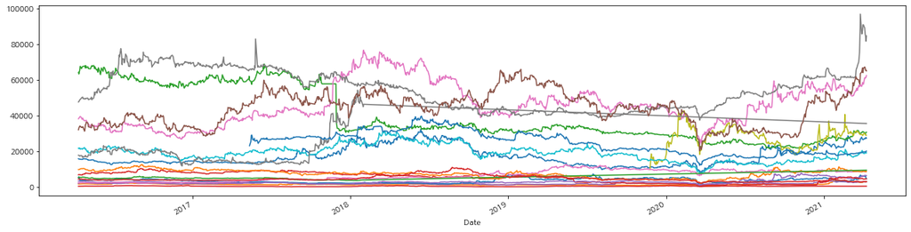

```python
plt.figure(figsize=(20, 5))
for d in dataset:
    d['Close'].plot()
```

```python
dataset
```

```
[               High      Low     Open    Close    Volume     Adj Close
 Date
 2016-04-11  16050.0  15700.0  16050.0  16000.0   27641.0  14377.058594
 2016-04-12  15900.0  15700.0  15800.0  15850.0   32428.0  14242.273438
 2016-04-14  15900.0  15450.0  15850.0  15800.0   66917.0  14197.346680
 2016-04-15  15900.0  15650.0  15700.0  15750.0   20894.0  14152.418945
 2016-04-18  15750.0  15500.0  15750.0  15650.0   39656.0  14062.560547
 ...             ...      ...      ...      ...       ...           ...
 2021-04-05  27450.0  26700.0  26850.0  27350.0  126491.0  27350.000000
 2021-04-06  27600.0  27050.0  27500.0  27200.0   75789.0  27200.000000
 2021-04-07  27700.0  26750.0  27300.0  27700.0  172740.0  27700.000000
 2021-04-08  28250.0  27200.0  27800.0  27950.0  170232.0  27950.000000
 2021-04-09  28150.0  27500.0  28000.0  27500.0   81833.0  27500.000000

 [1221 rows x 6 columns],
               High     Low    Open   Close      Volume    Adj Close
 Date
 2016-04-11  1940.0  1875.0  1915.0  1915.0    121437.0  1884.112915
 2016-04-12  1940.0  1900.0  1940.0  1915.0     28787.0  1884.112915
 2016-04-14  1950.0  1895.0  1950.0  1910.0     32320.0  1879.193604
 2016-04-15  1930.0  1900.0  1905.0  1930.0     37184.0  1898.870972
 2016-04-18  1985.0  1925.0  1950.0  1975.0    137777.0  1943.145142
 ...            ...     ...     ...     ...         ...          ...
 2021-04-05  3150.0  3025.0  3095.0  3140.0    413941.0  3140.000000
 2021-04-06  3180.0  3010.0  3180.0  3015.0    309418.0  3015.000000
 2021-04-07  3040.0  2940.0  3000.0  2980.0    275546.0  2980.000000
 2021-04-08  3770.0  2895.0  2955.0  3275.0  14703773.0  3275.000000
 2021-04-09  3335.0  3150.0  3335.0  3190.0   1784947.0  3190.000000

 [1221 rows x 6 columns],
                     High           Low          Open         Close   Volume  \
 Date
 2016-04-11  65407.113281  63626.523438  64101.347656  64338.757812   6571.0
 2016-04-12  64338.757812  62676.871094  64338.757812  63507.816406  13242.0
 2016-04-14  65763.234375  62439.460938  62676.871094  65763.234375   8721.0
 2016-04-15  68137.359375  64101.347656  64694.878906  67781.242188  14599.0
 2016-04-18  69087.007812  66119.351562  69087.007812  66475.468750   9861.0
 ...                  ...           ...           ...           ...      ...
 2021-04-05  30950.000000  30350.000000  30900.000000  30600.000000  24568.0
 2021-04-06  30650.000000  29850.000000  30600.000000  29850.000000  66241.0
```

[output cut: 321 more lines]

```
                High      Low     Open    Close    Volume     Adj Close
 Date
 2016-04-11  32650.0  31700.0  32000.0  32250.0  236932.0  31618.091797
 2016-04-12  33450.0  32200.0  32550.0  33250.0  235920.0  32598.498047
 2016-04-14  34500.0  33600.0  33650.0  34300.0  449734.0  33627.925781
 2016-04-15  35350.0  34100.0  34500.0  34250.0  319808.0  33578.906250
 2016-04-18  33650.0  32700.0  33600.0  33500.0  243482.0  32843.597656
 ...             ...      ...      ...      ...       ...           ...
 2021-04-05  69500.0  66500.0  67000.0  67400.0  490106.0  67400.000000
 2021-04-06  68200.0  66200.0  67700.0  67000.0  289167.0  67000.000000
 2021-04-07  67700.0  65500.0  67100.0  65500.0  299536.0  65500.000000
 2021-04-08  67300.0  65100.0  65900.0  65700.0  281102.0  65700.000000
 2021-04-09  66400.0  64700.0  66200.0  65200.0  190140.0  65200.000000

 [1221 rows x 6 columns]]
```

종가만 사용해서 하나의 데이터로 결합해 보겠습니다.

```python
ulsan_df = pd.concat([i['Close'] for i in dataset], axis=1)
ulsan_df.columns = company_df[company_df['지역']=='울산광역시' ]['회사명'].values
```

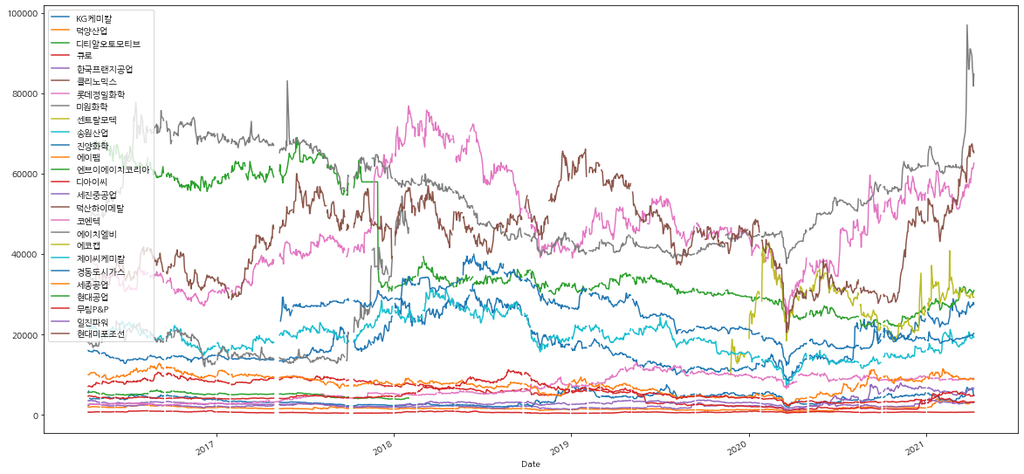

```python
ulsan_df.plot(figsize=(20, 10));
```

그림으로 그려서 한 번 훝어보겠습니다.

```python
import seaborn as sns
```

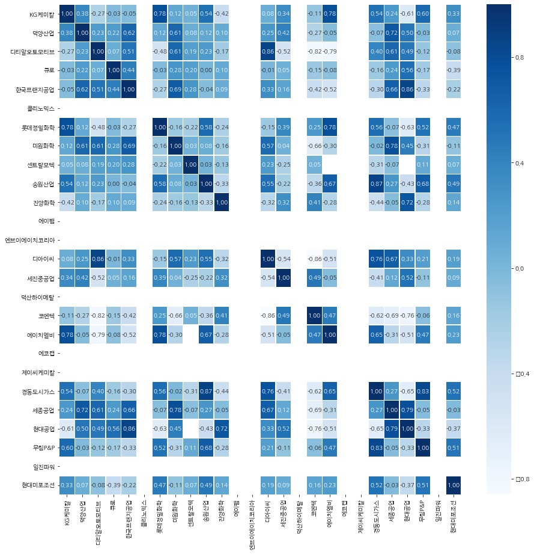

```python
plt.figure(figsize=(15,15))
sns.heatmap(data = ulsan_df.corr(),
            annot=True,
            fmt = '.2f',
            linewidths=.5,
            cmap='Blues');
```

corr 그래프에서 비어 있는 결측치들이 보이네요?

```python
ulsan_df.isnull().sum()
```

```
KG케미칼          72
덕양산업           72
디티알오토모티브       72
큐로             72
한국프랜지공업        72
클리노믹스        1292
롯데정밀화학         72
미원화학           72
센트랄모텍         953
송원산업           72
진양화학           72
에이팸          1292
엔브이에이치코리아    1292
디아이씨           72
세진중공업          72
덕산하이메탈       1292
코엔텍            38
에이치엘비         852
에코캡          1292
제이씨케미칼       1292
경동도시가스        339
세종공업           72
현대공업          852
무림P&P          72
일진파워         1292
현대미포조선         72
dtype: int64
```

- 데이터에 문제가 있는 기업들 목록

```python
ulsan_df.isnull().sum()[ulsan_df.isnull().sum() != 72].keys()
```

```
Index(['클리노믹스', '센트랄모텍', '에이팸', '엔브이에이치코리아', '덕산하이메탈', '코엔텍', '에이치엘비', '에코캡',
       '제이씨케미칼', '경동도시가스', '현대공업', '일진파워'],
      dtype='object')
```

데이터가 실제로 끊겨 있거나 없네요..

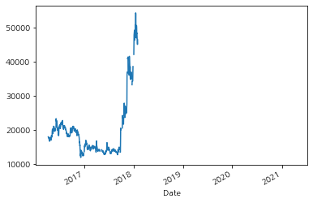

```python
ulsan_df['에이치엘비'].plot()
```

결측일이 72일인 기업들만 걸러 보겠습니다.

```python
ulsan_df.isnull().sum()[ulsan_df.isnull().sum() == 72].keys()
```

```
Index(['KG케미칼', '덕양산업', '디티알오토모티브', '큐로', '한국프랜지공업', '롯데정밀화학', '미원화학', '송원산업',
       '진양화학', '디아이씨', '세진중공업', '세종공업', '무림P&P', '현대미포조선'],
      dtype='object')
```

그럼 데이터가 올바르게 존재하는 기업들만 대상으로 새로 DataFrame을 만들겠습니다.

```python
new_df = ulsan_df[['KG케미칼', '덕양산업', '디티알오토모티브', '큐로', '한국프랜지공업', '롯데정밀화학', '미원화학', '송원산업',
       '진양화학', '디아이씨', '세진중공업', '세종공업', '무림P&P', '현대미포조선']]
```

```python
new_df
```

| Date | KG케미칼 | 덕양산업 | 디티알오토모티브 | 큐로 | 한국프랜지공업 | 롯데정밀화학 | 미원화학 | 송원산업 | 진양화학 | 디아이씨 | 세진중공업 | 세종공업 | 무림P&P | 현대미포조선 |
| --- | --- | --- | --- | --- | --- | --- | --- | --- | --- | --- | --- | --- | --- | --- |
| 2016-04-11 | 16000.0 | 1915.0 | 64338.757812 | 634.598206 | 3500.0 | 38400.0 | 47800.0 | 21900.0 | 5490.0 | 7055.091797 | 2293.333252 | 9980.0 | 4605.0 | 32250.0 |
| 2016-04-12 | 15850.0 | 1915.0 | 63507.816406 | 634.598206 | 3540.0 | 38750.0 | 48050.0 | 21650.0 | 5880.0 | 7161.183105 | 2353.333252 | 9950.0 | 4675.0 | 33250.0 |
| 2016-04-13 | NaN | NaN | NaN | NaN | NaN | NaN | NaN | NaN | NaN | NaN | NaN | NaN | NaN | NaN |
| 2016-04-14 | 15800.0 | 1910.0 | 65763.234375 | 646.622192 | 3440.0 | 39400.0 | 49000.0 | 22050.0 | 4120.0 | 7099.296387 | 2560.000000 | 10100.0 | 4725.0 | 34300.0 |
| 2016-04-15 | 15750.0 | 1930.0 | 67781.242188 | 643.282166 | 3530.0 | 39700.0 | 49200.0 | 21400.0 | 3970.0 | 7055.091797 | 2693.333252 | 10350.0 | 4685.0 | 34250.0 |
| ... | ... | ... | ... | ... | ... | ... | ... | ... | ... | ... | ... | ... | ... | ... |
| 2021-04-05 | 27350.0 | 3140.0 | 30600.000000 | 668.000000 | 3070.0 | 61400.0 | 89200.0 | 18950.0 | 6330.0 | 3200.000000 | 6690.000000 | 8940.0 | 4720.0 | 67400.0 |
| 2021-04-06 | 27200.0 | 3015.0 | 29850.000000 | 673.000000 | 3030.0 | 61200.0 | 86000.0 | 19300.0 | 6190.0 | 3160.000000 | 6640.000000 | 8800.0 | 4630.0 | 67000.0 |
| 2021-04-07 | 27700.0 | 2980.0 | 30300.000000 | 673.000000 | 3090.0 | 61200.0 | 84700.0 | 19800.0 | 6300.0 | 3120.000000 | 6670.000000 | 8730.0 | 4720.0 | 65500.0 |
| 2021-04-08 | 27950.0 | 3275.0 | 30600.000000 | 663.000000 | 3100.0 | 61700.0 | 81800.0 | 19400.0 | 4990.0 | 3120.000000 | 6610.000000 | 8950.0 | 4825.0 | 65700.0 |
| 2021-04-09 | 27500.0 | 3190.0 | 30900.000000 | 660.000000 | 3065.0 | 62600.0 | 84800.0 | 19300.0 | 4800.0 | 3185.000000 | 6580.000000 | 8850.0 | 4810.0 | 65200.0 |

1293 rows × 14 columns

이 값들에 대해 히트맵(heatmap)을 그려보겠습니다.

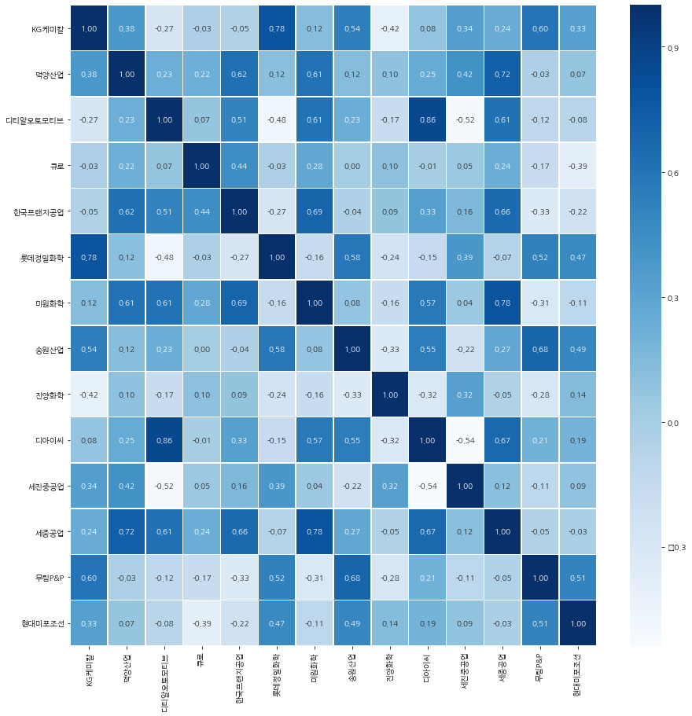

```python
plt.figure(figsize=(15,15))
sns.heatmap(data = new_df.corr(),
            annot=True,
            fmt = '.2f',
            linewidths=.5,
            cmap='Blues');
```

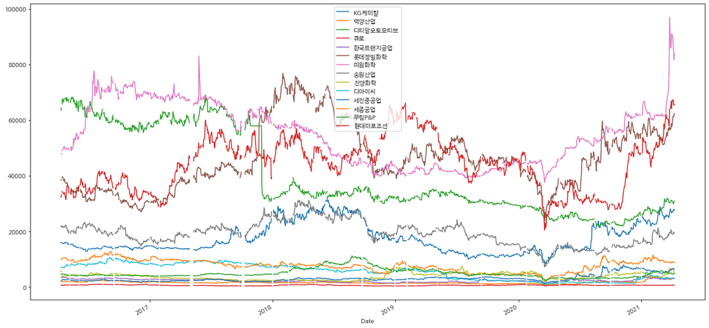

```python
new_df.plot(figsize=(20, 10));
```

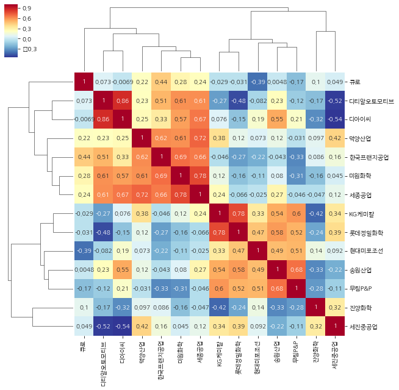

```python
sns.clustermap(new_df.corr(),
               annot=True,
               cmap='RdYlBu_r'
              );
```

클러스터맵(clustermap)을 그려보니 덕양산업과 관련이 있는 기업은 세 기업인 것 같네요.

```python
new_df[['덕양산업', '한국프랜지공업', '미원화학', '세종공업']]
```

| Date | 덕양산업 | 한국프랜지공업 | 미원화학 | 세종공업 |
| --- | --- | --- | --- | --- |
| 2016-04-11 | 1915.0 | 3500.0 | 47800.0 | 9980.0 |
| 2016-04-12 | 1915.0 | 3540.0 | 48050.0 | 9950.0 |
| 2016-04-13 | NaN | NaN | NaN | NaN |
| 2016-04-14 | 1910.0 | 3440.0 | 49000.0 | 10100.0 |
| 2016-04-15 | 1930.0 | 3530.0 | 49200.0 | 10350.0 |
| ... | ... | ... | ... | ... |
| 2021-04-05 | 3140.0 | 3070.0 | 89200.0 | 8940.0 |
| 2021-04-06 | 3015.0 | 3030.0 | 86000.0 | 8800.0 |
| 2021-04-07 | 2980.0 | 3090.0 | 84700.0 | 8730.0 |
| 2021-04-08 | 3275.0 | 3100.0 | 81800.0 | 8950.0 |
| 2021-04-09 | 3190.0 | 3065.0 | 84800.0 | 8850.0 |

1293 rows × 4 columns

앗차 NaN으로 결측치가 있네요. 거래소 휴일 등의 문제인 것 같습니다.

```python
new_df[['덕양산업', '한국프랜지공업', '미원화학', '세종공업']].isnull().sum()
```

```
덕양산업       72
한국프랜지공업    72
미원화학       72
세종공업       72
dtype: int64
```

이 72일 간의 결측일을 날리겠습니다.

```python
new_df[['덕양산업', '한국프랜지공업', '미원화학', '세종공업']].dropna()
```

[output not shown]

1221 rows × 4 columns

```python
target_df = new_df[['덕양산업', '한국프랜지공업', '미원화학', '세종공업']].dropna()
```

이제 이 최종 데이터를 들고서 새로 X, Y를 만들어 보겠습니다.

```python
dataset = []
for i in list(range(0, target_df.shape[0], 10)):
    if i == 0:
        continue

    for company_name in ['덕양산업', '한국프랜지공업', '미원화학', '세종공업']:
        dataset.append(
            target_df[company_name].iloc[i:i+10]
        )
```

```python
X = []
Y = []
for d in dataset:
    if d.shape[0] == 1:
        continue

    close = d.values
    X.append(close[:9])

    # 정답을 만들자
    if close[9] > close[8]:
        y = 1
    else:
        y = 0
    Y.append(
        np.array([y])
    )

X = np.array(X)
Y = np.array(Y)
```

# 신경망 학습

```python
from keras.models import Sequential
from keras.layers import Dense
from tqdm.keras import TqdmCallback
```

```python
model = Sequential()
model.add(Dense(18, input_dim=9, activation='relu'))
model.add(Dense(9, activation='relu'))
model.add(Dense(18, activation='relu'))
model.add(Dense(9, activation='relu'))
model.add(Dense(12, activation='relu'))
model.add(Dense(1, activation='sigmoid'))
model.compile(loss='binary_crossentropy' , optimizer='adam', metrics=['accuracy'])
```

```python
history = model.fit(X, Y,
                    epochs=10000,
                    verbose=0,
                    callbacks=[TqdmCallback(verbose=0)]
                   )
```

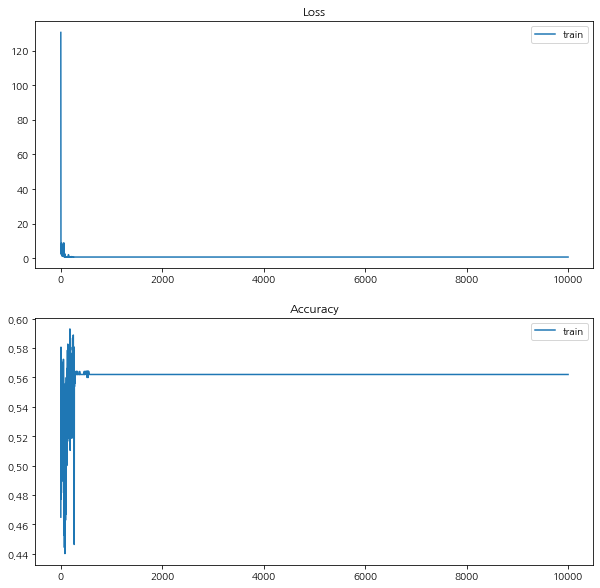

```python
plt.figure(figsize=(10, 10))

plt.subplot(211)
plt.title('Loss')
plt.plot(history.history['loss'], label='train')
# plt.plot(history.history['val_loss'], label='test')
plt.legend()

plt.subplot(212)
plt.title('Accuracy')
plt.plot(history.history['accuracy'], label='train')
# plt.plot(history.history['val_accuracy'], label='test')
plt.legend()
```

```python
model = Sequential()
model.add(Dense(18, input_dim=9, activation='relu'))
model.add(Dense(9, activation='relu'))
model.add(Dense(12, activation='relu'))
model.add(Dense(1, activation='sigmoid'))
model.compile(loss='binary_crossentropy' , optimizer='adam', metrics=['accuracy'])
```

```python
history_2 = model.fit(X, Y,
                    epochs=1000,
                    verbose=0,
                    callbacks=[TqdmCallback(verbose=0)]
                   )
```

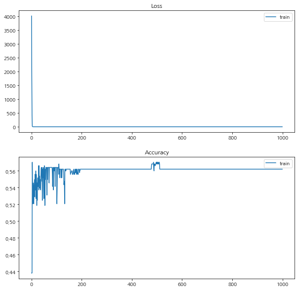

```python
plt.figure(figsize=(10, 10))

plt.subplot(211)
plt.title('Loss')
plt.plot(history_2.history['loss'], label='train')
# plt.plot(history.history['val_loss'], label='test')
plt.legend()

plt.subplot(212)
plt.title('Accuracy')
plt.plot(history_2.history['accuracy'], label='train')
# plt.plot(history.history['val_accuracy'], label='test')
plt.legend()
```